# Q & K Box 13.2

Mayekar et al (2017) studied some potential determinants of colour (green vs brown) of a tropical butterfly species. A laboratory population was established, and newly hatched larvae were placed in a growth chamber set at either 60% or 85% relative humidity. Resulting pupae were recorded for colour, time to pupation, pupal weight and sex. We will use their data to model green vs brown pupae against the two continuous predictors (time to pupation, pupal weight) and the one categorical predictor (sex). We will only use data from the low humidity treatment as brown pupae were very uncommon at high humidity.

Mayekar, H. V. & Kodandaramaiah, U. (2017). Pupal colour plasticity in a tropical butterfly, *Mycalesis mineus* (Nymphalidae: Satyrinae). *PLoS One*, 12, e0171482.

The paper is [here](https://doi.org/10.1371/journal.pone.0171482), and Figure 1 is an excellent image of the divergent colour phenotypes.

### Preliminaries

First, load the required packages (car, performance, MuMIn)

Import mayekar data file (mayekar.csv)

```r
mayekar <- read.csv("../data/mayekar.csv")
mayekar
```

| rh | colour | timepup | subst | sex | weight | colnum |
| --- | --- | --- | --- | --- | --- | --- |
| low | green | 19 | leaf | male | 0.1590 | 1 |
| low | green | 21 | leaf | female | 0.2511 | 1 |
| low | green | 19 | leaf | male | 0.2289 | 1 |
| low | green | 21 | off-leaf | male | 0.1960 | 1 |
| low | green | 21 | off-leaf | male | 0.1178 | 1 |
| low | green | 21 | off-leaf | female | 0.2312 | 1 |
| low | green | 21 | off-leaf | female | 0.2409 | 1 |
| low | green | 21 | leaf | male | 0.1958 | 1 |
| low | green | 21 | leaf | male | 0.1818 | 1 |
| low | green | 19 | leaf | male | 0.1962 | 1 |

[output cut: 691 more lines]

Create subset of the low-humidity treatment

```r
#select rh = low
mayekar1 <- subset(mayekar, rh=="low")
```

### Do simple plots for cont. predictors

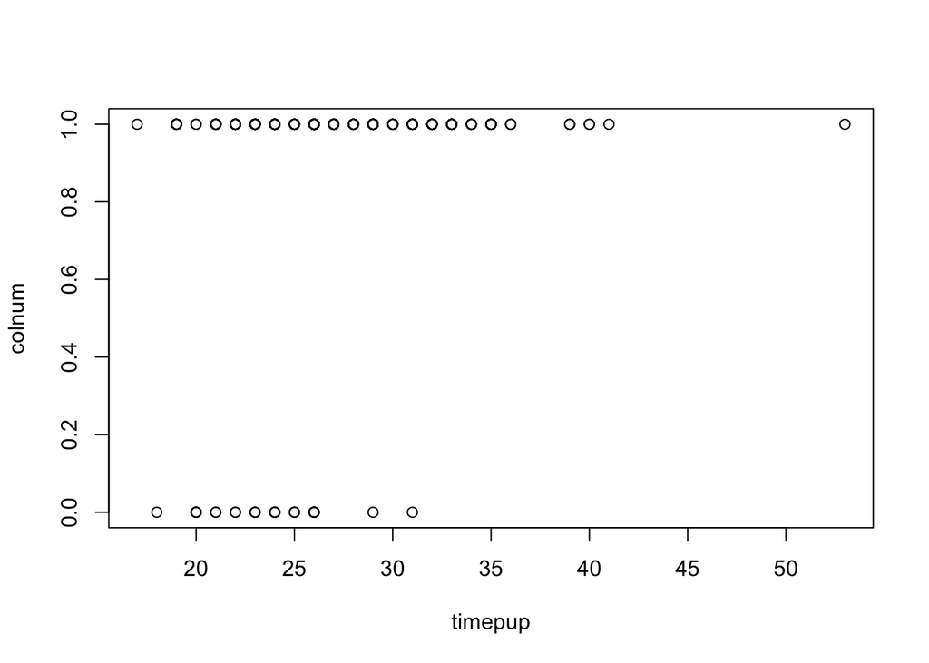

```r
plot(colnum~timepup, data=mayekar1)
```

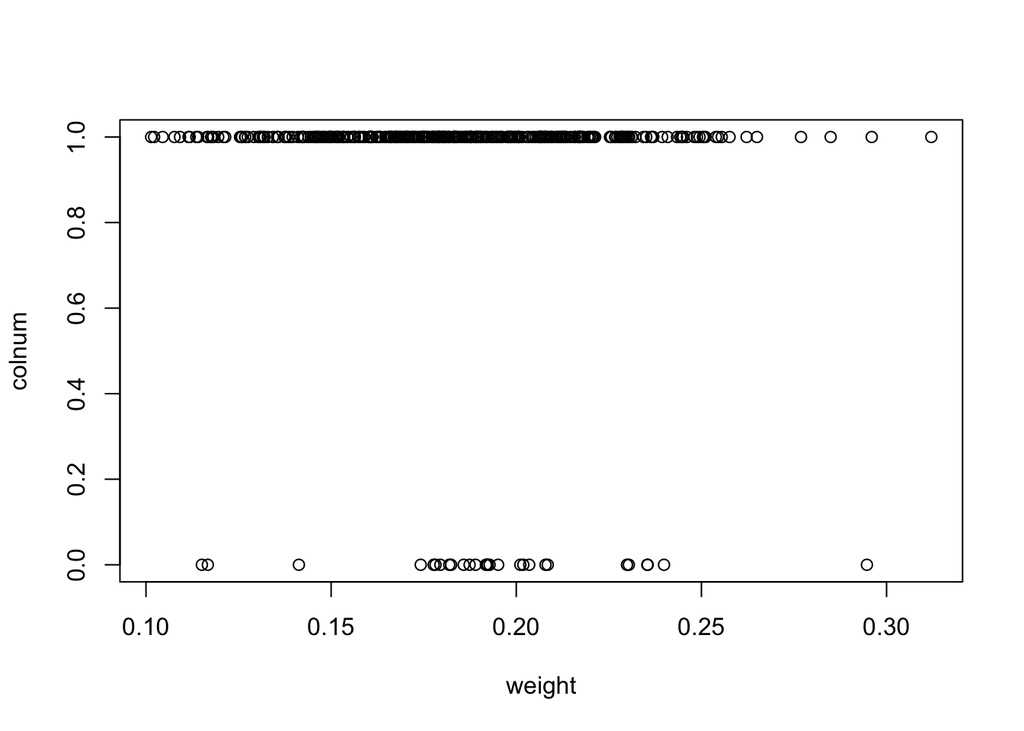

```r
plot(colnum~weight, data=mayekar1)
```

### Fit full glm

```r
mayekar1.glm <- glm(colnum ~ timepup*weight*sex,data=mayekar1,family=binomial)
tidy(mayekar1.glm)
```

| term | estimate | std.error | statistic | p.value |
| --- | --- | --- | --- | --- |
| (Intercept) | -4.3574149 | 11.5352376 | -0.3777482 | 0.7056177 |
| timepup | 0.3200181 | 0.4704058 | 0.6803022 | 0.4963131 |
| weight | 6.0281902 | 55.4602272 | 0.1086939 | 0.9134453 |
| sexmale | -11.9308545 | 16.9165553 | -0.7052768 | 0.4806380 |
| timepup:weight | -0.4881998 | 2.2894712 | -0.2132369 | 0.8311422 |
| timepup:sexmale | 0.3403070 | 0.6759649 | 0.5034389 | 0.6146557 |
| weight:sexmale | 67.8920087 | 87.3741476 | 0.7770263 | 0.4371433 |
| timepup:weight:sexmale | -1.9455382 | 3.5268246 | -0.5516402 | 0.5811949 |

```r
glance(mayekar1.glm)
```

| null.deviance | df.null | logLik | AIC | BIC | deviance | df.residual | nobs |
| --- | --- | --- | --- | --- | --- | --- | --- |
| 201.1418 | 387 | -90.46003 | 196.9201 | 228.6081 | 180.9201 | 380 | 388 |

```r
AICc(mayekar1.glm)
```

```
## [1] 197.3
```

#### Check collinearity

```r
vif(lm(colnum ~ timepup*weight*sex, data=mayekar1))
```

```
## there are higher-order terms (interactions) in this model
## consider setting type = 'predictor'; see ?vif
```

```
##            timepup             weight                sex     timepup:weight
##           63.49941           76.45463         1056.56148           97.30631
##        timepup:sex         weight:sex timepup:weight:sex
##          963.69503          863.07185          775.78199
```

```r
cor(mayekar1$timepup,mayekar1$weight)
```

```
## [1] -0.3210386
```

```r
aov1 <-aov(timepup~sex, data=mayekar1)
summary(aov1)
```

```
##              Df Sum Sq Mean Sq F value Pr(>F)
## sex           1     50   49.55   2.334  0.127
## Residuals   386   8195   21.23
```

```r
aov2 <- aov(weight~sex, data=mayekar1)
summary(aov2)
```

```
##              Df Sum Sq Mean Sq F value   Pr(>F)
## sex           1 0.0459 0.04594   38.15 1.66e-09 ***
## Residuals   386 0.4649 0.00120
## ---
## Signif. codes:  0 '***' 0.001 '**' 0.01 '*' 0.05 '.' 0.1 ' ' 1
```

Try centering continuous predictors to reduce collinearity

```r
mayekar1$ctimepup <- scale(mayekar1$timepup, center=TRUE, scale=FALSE)
mayekar1$cweight <- scale(mayekar1$weight, center=TRUE, scale=FALSE)
vif(lm(colnum ~ ctimepup*cweight*sex, data=mayekar1))
```

```
## there are higher-order terms (interactions) in this model
## consider setting type = 'predictor'; see ?vif
```

```
##             ctimepup              cweight                  sex
##             2.208458             2.038322             1.228514
##     ctimepup:cweight         ctimepup:sex          cweight:sex
##             2.489793             2.194983             2.099961
## ctimepup:cweight:sex
##             2.616700
```

## Centred predictors

Fit full model

```r
mayekar2.glm <- glm(colnum ~ ctimepup*cweight*sex,data=mayekar1,family=binomial)
summary(mayekar2.glm)
```

```
##
## Call:
## glm(formula = colnum ~ ctimepup * cweight * sex, family = binomial,
##     data = mayekar1)
##
## Coefficients:
##                          Estimate Std. Error z value Pr(>|z|)
## (Intercept)               2.93819    0.38024   7.727  1.1e-14 ***
## ctimepup                  0.22977    0.09352   2.457    0.014 *
## cweight                  -7.10539   10.06451  -0.706    0.480
## sexmale                   0.09931    0.60867   0.163    0.870
## ctimepup:cweight         -0.48820    2.28947  -0.213    0.831
## ctimepup:sexmale         -0.01935    0.13493  -0.143    0.886
## cweight:sexmale          15.55302   16.02256   0.971    0.332
## ctimepup:cweight:sexmale -1.94554    3.52682  -0.552    0.581
## ---
## Signif. codes:  0 '***' 0.001 '**' 0.01 '*' 0.05 '.' 0.1 ' ' 1
##
## (Dispersion parameter for binomial family taken to be 1)
##
##     Null deviance: 201.14  on 387  degrees of freedom
## Residual deviance: 180.92  on 380  degrees of freedom
## AIC: 196.92
##
## Number of Fisher Scoring iterations: 6
```

```r
AICc(mayekar2.glm)
```

```
## [1] 197.3
```

Fit no interaction model

```r
mayekar3.glm <- glm(colnum ~ ctimepup+cweight+sex,data=mayekar1,family=binomial)
summary(mayekar3.glm)
```

```
##
## Call:
## glm(formula = colnum ~ ctimepup + cweight + sex, family = binomial,
##     data = mayekar1)
##
## Coefficients:
##             Estimate Std. Error z value Pr(>|z|)
## (Intercept)  2.79243    0.31341   8.910  < 2e-16 ***
## ctimepup     0.22058    0.06296   3.504 0.000459 ***
## cweight      0.44017    6.35219   0.069 0.944755
## sexmale      0.25680    0.43507   0.590 0.555023
## ---
## Signif. codes:  0 '***' 0.001 '**' 0.01 '*' 0.05 '.' 0.1 ' ' 1
##
## (Dispersion parameter for binomial family taken to be 1)
##
##     Null deviance: 201.14  on 387  degrees of freedom
## Residual deviance: 183.93  on 384  degrees of freedom
## AIC: 191.93
##
## Number of Fisher Scoring iterations: 6
```

```r
AICc(mayekar3.glm)
```

```
## [1] 192.0376
```

Compare the two models

```r
anova(mayekar2.glm, mayekar3.glm, test = 'Chisq')
```

|  | Resid. Df | Resid. Dev | Df | Deviance | Pr(>Chi) |
| --- | --- | --- | --- | --- | --- |
| 1 | 380 | 180.9201 | NA | NA | NA |
| 2 | 384 | 183.9332 | -4 | -3.013115 | 0.5556331 |

### For interest, see if not centering would have changed our conclusions

#### Fit uncentered no interaction model

```r
mayekar4.glm <- glm(colnum ~ timepup+weight+sex,data=mayekar1,family=binomial)
summary(mayekar4.glm)
```

```
##
## Call:
## glm(formula = colnum ~ timepup + weight + sex, family = binomial,
##     data = mayekar1)
##
## Coefficients:
##             Estimate Std. Error z value Pr(>|z|)
## (Intercept) -3.22297    2.33228  -1.382 0.167005
## timepup      0.22058    0.06296   3.504 0.000459 ***
## weight       0.44017    6.35219   0.069 0.944755
## sexmale      0.25680    0.43507   0.590 0.555023
## ---
## Signif. codes:  0 '***' 0.001 '**' 0.01 '*' 0.05 '.' 0.1 ' ' 1
##
## (Dispersion parameter for binomial family taken to be 1)
##
##     Null deviance: 201.14  on 387  degrees of freedom
## Residual deviance: 183.93  on 384  degrees of freedom
## AIC: 191.93
##
## Number of Fisher Scoring iterations: 6
```

```r
AICc(mayekar4.glm)
```

```
## [1] 192.0376
```

Compare to full model (uncentered)

```r
anova(mayekar1.glm, mayekar4.glm, test = 'Chisq')
```

|  | Resid. Df | Resid. Dev | Df | Deviance | Pr(>Chi) |
| --- | --- | --- | --- | --- | --- |
| 1 | 380 | 180.9201 | NA | NA | NA |
| 2 | 384 | 183.9332 | -4 | -3.013115 | 0.5556331 |

Same results as for centered analysis

### Focus on fit of no interaction model with uncentered data

```r
summary(mayekar4.glm)
```

```
##
## Call:
## glm(formula = colnum ~ timepup + weight + sex, family = binomial,
##     data = mayekar1)
##
## Coefficients:
##             Estimate Std. Error z value Pr(>|z|)
## (Intercept) -3.22297    2.33228  -1.382 0.167005
## timepup      0.22058    0.06296   3.504 0.000459 ***
## weight       0.44017    6.35219   0.069 0.944755
## sexmale      0.25680    0.43507   0.590 0.555023
## ---
## Signif. codes:  0 '***' 0.001 '**' 0.01 '*' 0.05 '.' 0.1 ' ' 1
##
## (Dispersion parameter for binomial family taken to be 1)
##
##     Null deviance: 201.14  on 387  degrees of freedom
## Residual deviance: 183.93  on 384  degrees of freedom
## AIC: 191.93
##
## Number of Fisher Scoring iterations: 6
```

```r
AICc(mayekar4.glm)
```

```
## [1] 192.0376
```

```r
confint(mayekar4.glm)
```

```
##                   2.5 %     97.5 %
## (Intercept)  -7.8506708  1.3345565
## timepup       0.1027640  0.3502998
## weight      -12.0276103 12.9633553
## sexmale      -0.5942655  1.1258285
```

```r
anova(mayekar4.glm, test = 'Chisq')
```

|  | Df | Deviance | Resid. Df | Resid. Dev | Pr(>Chi) |
| --- | --- | --- | --- | --- | --- |
| NULL | NA | NA | 387 | 201.1418 | NA |
| timepup | 1 | 16.83624551 | 386 | 184.3055 | 4.074757e-05 |
| weight | 1 | 0.02234333 | 385 | 184.2832 | 8.811774e-01 |
| sex | 1 | 0.35002882 | 384 | 183.9332 | 5.540968e-01 |

### Create reduced models for lrtests

Remove each of the individual predictors

Note slight differences in P values for continuous predictors - lrtest more reliable

```r
mayekar5.glm <- glm(colnum ~ timepup+weight,data=mayekar1,family=binomial)
mayekar6.glm <- glm(colnum ~ timepup+sex,data=mayekar1,family=binomial)
mayekar7.glm <- glm(colnum ~ weight+sex,data=mayekar1,family=binomial)
lrtest(mayekar5.glm, mayekar4.glm)
```

|  | #Df | LogLik | Df | Chisq | Pr(>Chisq) |
| --- | --- | --- | --- | --- | --- |
| 1 | 3 | -92.14160 | NA | NA | NA |
| 2 | 4 | -91.96659 | 1 | 0.3500288 | 0.5540968 |

```r
lrtest(mayekar6.glm, mayekar4.glm)
```

|  | #Df | LogLik | Df | Chisq | Pr(>Chisq) |
| --- | --- | --- | --- | --- | --- |
| 1 | 3 | -91.96899 | NA | NA | NA |
| 2 | 4 | -91.96659 | 1 | 0.004802464 | 0.944751 |

```r
lrtest(mayekar7.glm, mayekar4.glm)
```

|  | #Df | LogLik | Df | Chisq | Pr(>Chisq) |
| --- | --- | --- | --- | --- | --- |
| 1 | 3 | -99.35540 | NA | NA | NA |
| 2 | 4 | -91.96659 | 1 | 14.77763 | 0.0001209619 |

#### Check assumptions for the simple (no interaction) model

Get and plot residuals - focus on deviance residuals plot

```r
residuals(mayekar4.glm, type="deviance")
```

[output not shown]

[output cut: 75 more lines]

[output not shown]

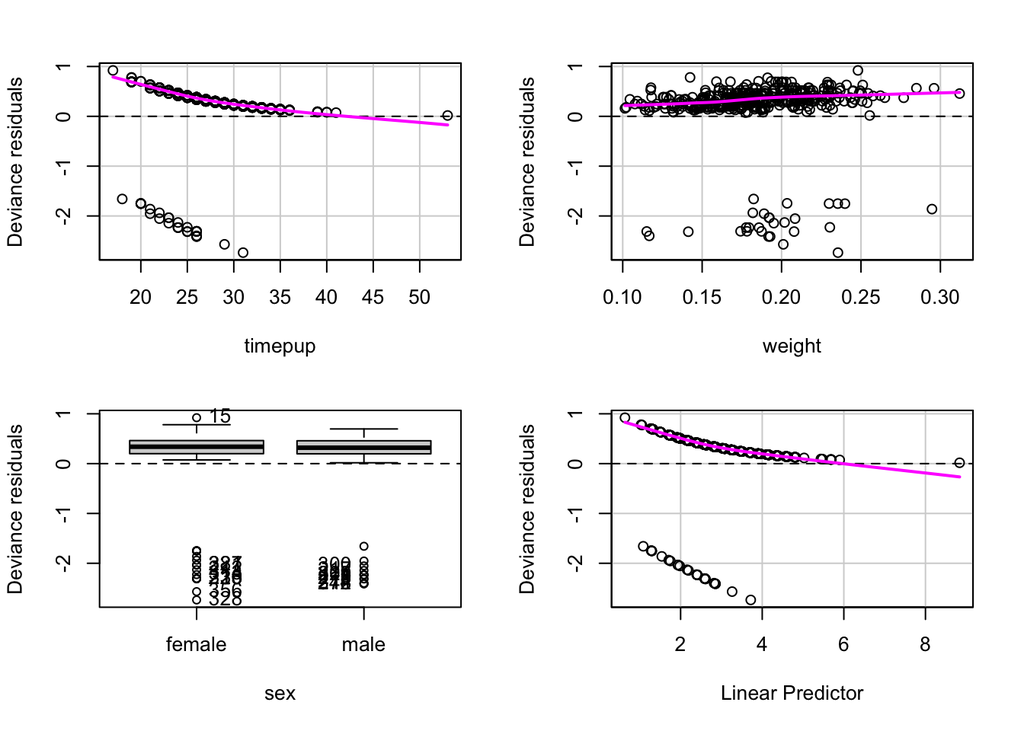

```
##         Test stat Pr(>|Test stat|)
## timepup    1.4111           0.2349
## weight     0.0051           0.9429
## sex
```

```r
residualPlots(mayekar4.glm, type="deviance")
```

Check influence diagnostics

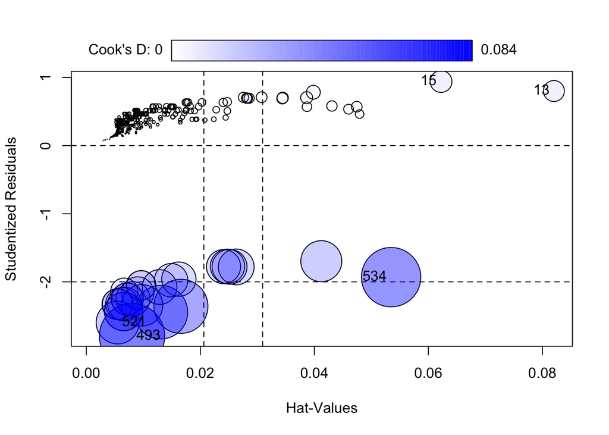

|  | StudRes | Hat | CookD |
| --- | --- | --- | --- |
| 13 | 0.8012893 | 0.082022413 | 0.008681118 |
| 15 | 0.9406532 | 0.062226092 | 0.009364181 |
| 493 | -2.7961660 | 0.008023592 | 0.084002154 |
| 521 | -2.5969406 | 0.005494443 | 0.036263112 |
| 534 | -1.9312862 | 0.053465654 | 0.069515481 |

```r
influencePlot(mayekar4.glm)
```

### Examine some alternative assessments

Get odds ratio with CI

```r
exp(coef(mayekar4.glm))
```

```
## (Intercept)     timepup      weight     sexmale
##  0.03983672  1.24679823  1.55297400  1.29278266
```

```r
exp(confint.default(mayekar4.glm))
```

```
##                    2.5 %       97.5 %
## (Intercept) 4.121350e-04 3.850593e+00
## timepup     1.102062e+00 1.410543e+00
## weight      6.083771e-06 3.964200e+05
## sexmale     5.510580e-01 3.032870e+00
```

Get added variable plots - hard to interpret

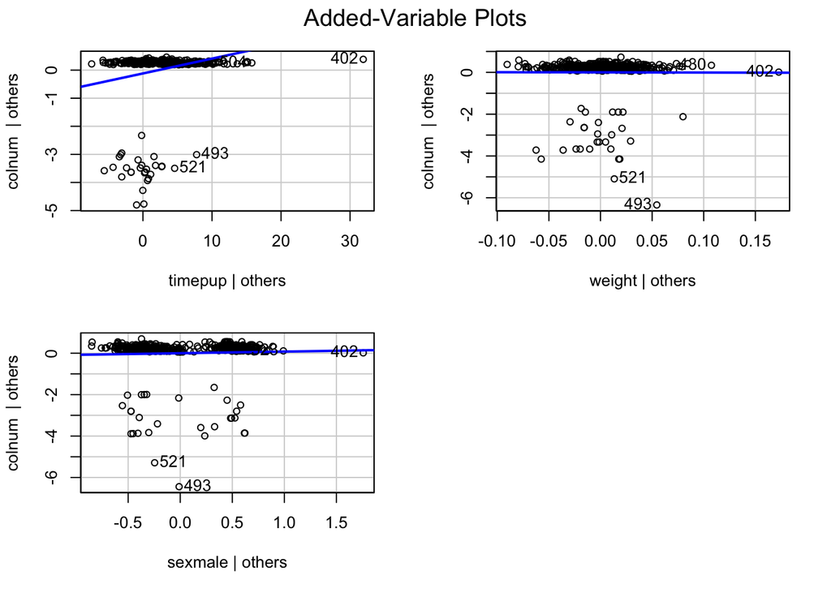

```r
avPlots(mayekar4.glm)
```

Get H-L test and Tjur r<sup>2</sup>

```r
performance_hosmer(mayekar4.glm, n_bins=10)
```

```
## # Hosmer-Lemeshow Goodness-of-Fit Test
##
##   Chi-squared: 6.877
##            df: 8
##       p-value: 0.550
```

```
## Summary: model seems to fit well.
```

```r
r2_tjur(mayekar4.glm)
```

```
##  Tjur's R2
## 0.04331007
```